# MRtree-tutorial

In this tutorial we illustrate the usage of MRtree functions using a simulated dataset. The data is simulated from SymSim by supplying a tree structure as shown below, containing UMI counts of 500 cells on 500 genes:

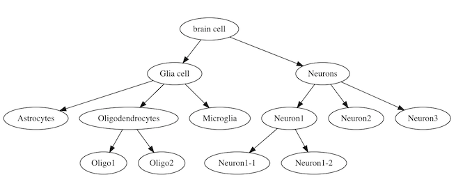

```r
library(mrtree)
```

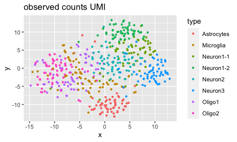

```r
# # The data simulation can be performed using SymSim package with the following wrapper function,
# # The following simulation code take some time to run (skip to load data with data("data_example"))
# tree = tree1(plot=T)$phylo.tree
# symsim.param.zeisel = list(gene_effects_sd=2, sigma=0.2, scale_s=0.4, alpha_mean=0.5, alpha_sd=0.025,
#                            depth_mean=2e5,depth_sd=1.5e4, nPCR1=14, prop_hge=0.01, mean_hge=3)
# ngenes = 500
# ncells = 500
# truek = 8; min_popsize = floor(ncells/truek)
# i_minpop =  which(tree$tip.label=='Microglia')
#
# seed = 1 # 0
# simu.out = generateDataSymSim(ncells=ncells, ngenes=ngenes, tree=tree,
#                               params=symsim.param.zeisel, plot.tsne=T,
#                               i_minpop=i_minpop, min_popsize=min_popsize,
#                               nevf=100, n_de_evf=30, sigma=0.7, seed=seed)
# simu.out$tsne_UMI_counts
# # data_example = simu.out; usethis::use_data(data_example)
# dat = simu.out


data("data_example", package = 'mrtree') # load data
dat = data_example
# tsne plot of 500 cells
dat$tsne_UMI_counts
```

The main function to perform MRtree analysis is `mrtree()`, where the data input is one of the following:

- An n-by-m matrix of labels, where n is the number of cells, m is the number of clustering resolutions
- A dataframe, with the targeted column prefix/suffix specified in prefix /suffix
- Seurat object with multiresolution clustering results
- SingleCellExperiment (SC3) object with multiresolution clustering results

`sc_clustering_methods.R` file provide a few clustering warppers including:

- `sc_clustering.seurat`, graph clustering provided by [Seurat](https://satijalab.org/seurat/) package (Butler et al. (2018))
- `sc_clustering.sc3`, Consensus clustering provided by SC3 package (Kiselev et al. (2017))
- `sc_clustering.simlr`, SIMLAR clustering provided by SIMLR package (Wang et al. (2017))
- `sc_clustering.soup`, Semi-soft clustering provided in [SOUP](https://github.com/lingxuez/SOUPR) package (Zhu et al. (2019))
- `sc_clustering.tsne_kmeans`, TSNE + Kmeans clustering
- `sc_clustering.umap_kmeans`, UMAP + Kmeans clustering

### MRtree with Seurat clustering

As first step, multi-resolution flat clustering is conducted using Seurat with a range of resolution parameters. The results can be visualized using a cluster tree, where each layer represent one clustering, the tree nodes represent clusters, and edge exists between clusters in adjacent layers if two clusters share data points.

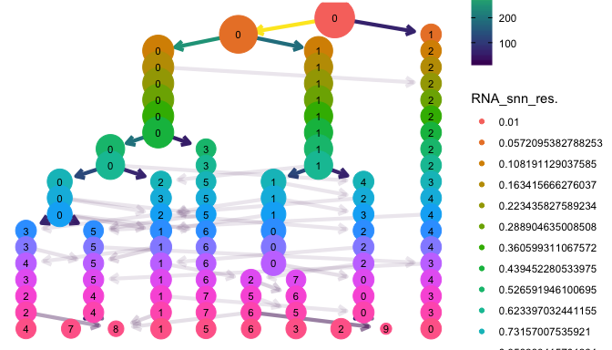

```r
set.seed(1)

counts = dat$counts
metadata = dat$metadata
rownames(metadata) = dat$metadata$cellid
ref.labels = dat$metadata$type

# specify the resolution parameters
# resolutions = seq(0.1, sqrt(3), 0.05)^2

# alternatively and preferrably, we provide a sampling tool to sample resolution parameters to uniformly cover different scales
A = seurat_get_nn_graph(counts=counts, metadata=metadata, npc=10)
resolutions = modularity_event_sampling(A=A, n.res=20, gamma.min=0.01, gamma.max=3) # sample based on the similarity matrix

# clustering using Suerat
seurat.out = sc_clustering.seurat(counts=counts, resolutions=resolutions, metadata=metadata, npcs=10,
                                  min.cells=0, min.features=0, scale.factor=10000, return.seurat.object=T,
                                  vars.to.regress=NULL, find.variable.features=F, verbose=F)

# initial cluster tree from Seurat flat clustering
plot_clustree(labelmat=seurat.out$seurat.clusters, prefix ='RNA_snn_res.',
              ref.labels = ref.labels, plot.ref = F)
```

Then we apply MRtree to ubtain the hierarchical cluster tree, visualized using a dendrogram, with a pie chart on each tree node detailing the cluster composition given the known true labels.

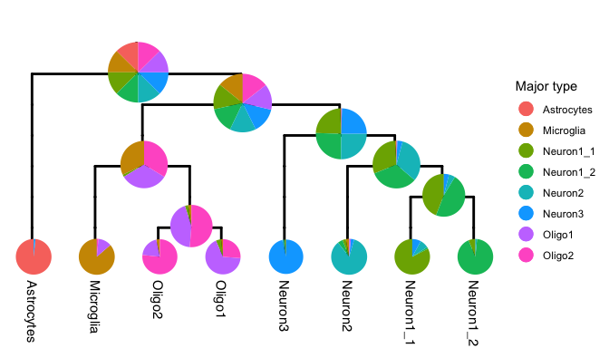

```r
out = mrtree(seurat.out$obj, consensus=T, sample.weighted=F)
# if there are few partitions per k, within resolution consensus step can speed up the algorithm
# weight per sample is encoraged if the classes are imbalanced

plot_tree_with_piechart(labelmat=out$labelmat.mrtree, ref.labels=ref.labels, draw.pie.chart=TRUE,
                        pie.size.offset=1, show.ref.labels = T, tip.label.dist = 10, bottom.margin=30 )
```

We evaluate te per-resolution clustering performance with a novel index adapted from Adjusted Rand Index to accrount for te bias for resolution.

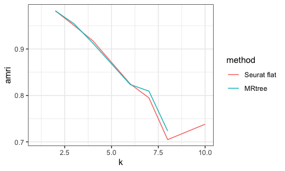

```r
ks.flat = apply(out$labelmat.flat, 2, FUN=function(x) length(unique(x)))
ks.mrtree = apply(out$labelmat.mrtree, 2, FUN=function(x) length(unique(x)))
amri.flat = sapply(1:ncol(out$labelmat.flat), function(i) AMRI(out$labelmat.flat[,i], ref.labels)$amri)
amri.flat = aggregate(amri.flat, by=list(k=ks.flat), FUN=mean)
amri.recon = sapply(1:ncol(out$labelmat.mrtree), function(i) AMRI(out$labelmat.mrtree[,i], ref.labels)$amri)

df = rbind(data.frame(k=amri.flat$k, amri=amri.flat$x, method='Seurat flat'),
           data.frame(k=ks.mrtree, amri=amri.recon, method='MRtree'))
ggplot2::ggplot(data=df, aes(x=k, y=amri, color=method)) + geom_line() + theme_bw()
```

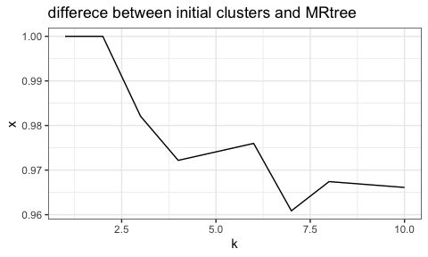

```r
diff = get_index_per_layer(labelmat1=out$labelmat.flat, labelmat2=out$labelmat.recon, index.name='ari')
df = aggregate(diff, by=list(k=apply(out$labelmat.flat, 2, FUN=function(x) length(unique(x)))), FUN=mean)

ggplot2::ggplot(data=df, aes(x=k, y=x)) + geom_line() + theme_bw() + labs(title='differece between initial clusters and MRtree')
```

### MRtree with SC3 clustering

```r
ks = 2:10
clusterings.per.k = 1

set.seed(1)
clust.out =  sc_clustering.sc3(exprs=counts, Ks=rep(ks, each=clusterings.per.k), type = 'counts', colData=metadata,
                                biology = F, n_cores = NULL, gene_filter = F, pct_dropout_min=-1)
```

Plot the initial clustering reults from SC3

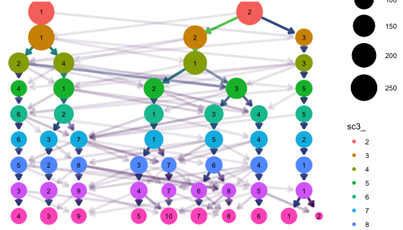

```r
plot_clustree(labelmat=clust.out$sce@colData, prefix='sc3_', suffix = "_clusters",
              ref.labels = ref.labels, plot.ref = F)
```

Run MrTree and plot the tree:

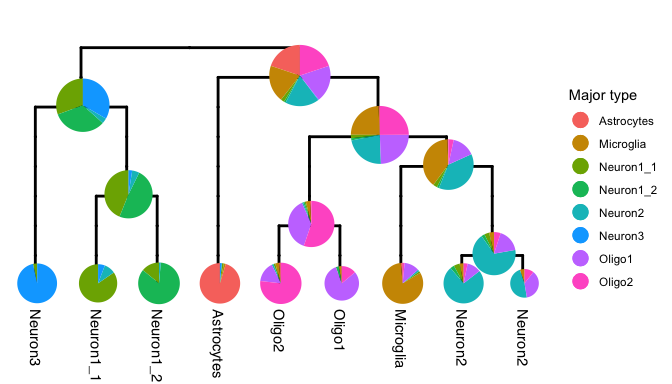

```r
out = mrtree(clust.out$sce, prefix='sc3_', suffix = "_clusters", consensus=F, sample.weighted=F)

plot_tree_with_piechart(labelmat=out$labelmat.mrtree, ref.labels=ref.labels, draw.pie.chart=TRUE,
                        pie.size.offset=1, show.ref.labels = T, tip.label.dist = 10, bottom.margin=30 )
```

We evaluate te per-resolution clustering performance via AMRI:

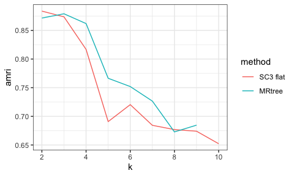

```r
ks.flat = apply(out$labelmat.flat, 2, FUN=function(x) length(unique(x)))
ks.mrtree = apply(out$labelmat.mrtree, 2, FUN=function(x) length(unique(x)))
amri.flat = sapply(1:ncol(out$labelmat.flat), function(i) AMRI(out$labelmat.flat[,i], ref.labels)$amri)
amri.flat = aggregate(amri.flat, by=list(k=ks.flat), FUN=mean)
amri.recon = sapply(1:ncol(out$labelmat.mrtree), function(i) AMRI(out$labelmat.mrtree[,i], ref.labels)$amri)

df = rbind(data.frame(k=amri.flat$k, amri=amri.flat$x, method='SC3 flat'),
           data.frame(k=ks.mrtree, amri=amri.recon, method='MRtree'))
ggplot2::ggplot(data=df, aes(x=k, y=amri, color=method)) + geom_line() + theme_bw()
```

We calcuate the similarity between the initial flat clustering and MRtree clusters across scales.

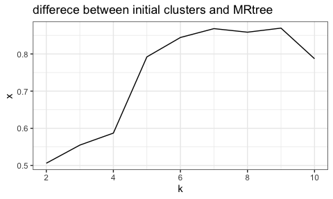

```r
diff = get_index_per_layer(labelmat1=out$labelmat.flat, labelmat2=out$labelmat.recon, index.name='ari')
df = aggregate(diff, by=list(k=apply(out$labelmat.flat, 2, FUN=function(x) length(unique(x)))), FUN=mean)

ggplot2::ggplot(data=df, aes(x=k, y=x)) + geom_line() + theme_bw() + labs(title='differece between initial clusters and MRtree')
```

# Reference

Butler, A., P. Hoffman, P. Smibert, E. Papalexi, and R. Satija. 2018. “Integrating Single-Cell Transcriptomic Data Across Different Conditions, Technologies, and Species.” Journal Article. *Nature Biotechnology* 36 (5): 411–+.

Kiselev, V. Y., K. Kirschner, M. T. Schaub, T. Andrews, A. Yiu, T. Chandra, K. N. Natarajan, et al. 2017. “SC3: Consensus Clustering of Single-Cell Rna-Seq Data.” *Nature Methods* 14 (5): 483–+.

Wang, B., J. J. Zhu, E. Pierson, D. Ramazzotti, and S. Batzoglou. 2017. “Visualization and Analysis of Single-Cell Rna-Seq Data by Kernel-Based Similarity Learning.” Journal Article. *Nature Methods* 14 (4): 414–+.

Zhu, Lingxue, Jing Lei, Lambertus Klei, Bernie Devlin, and Kathryn Roeder. 2019. “Semisoft Clustering of Single-Cell Data.” *Proceedings of the National Academy of Sciences* 116 (2): 466–71.